# Using the University of Southampton colour palettes

```r
library(tidyverse)
library(sotoncolours)
library(dichromat)
library(colorspace)
library(palmerpenguins)
library(raster)
library(patchwork)
```

# Introduction

The [**sotoncolours**](https://github.com/ab604/sotoncolours) package contains colour palettes based on the University of Southampton colour scheme.

# Installation

```r
devtools::install_github("ab604/sotoncolours", build_vignettes = TRUE)
```

# Colour and palette choices

The package contains 19 colours and 7 colour palettes.

```r
# Names of the colours
names(uos_cols())
```

```
##  [1] "black"    "neutral1" "neutral2" "neutral3" "neutral4" "marine1"
##  [7] "marine2"  "marine3"  "marine4"  "marine5"  "marine6"  "horizon1"
## [13] "horizon2" "horizon3" "horizon4" "horizon5" "prussian" "shamrock"
## [19] "coral"
```

```r
# See names of all palettes
names(uos_palettes)
```

```
## [1] "marine"    "horizon"   "neutral"   "web"       "contrast1" "contrast2"
## [7] "contrast3"
```

To see the colours in a palette by name

```r
# See names of all palettes
names(uos_palettes$contrast1)
```

```
## [1] "marine1"  "horizon3" "horizon2" "neutral2"
```

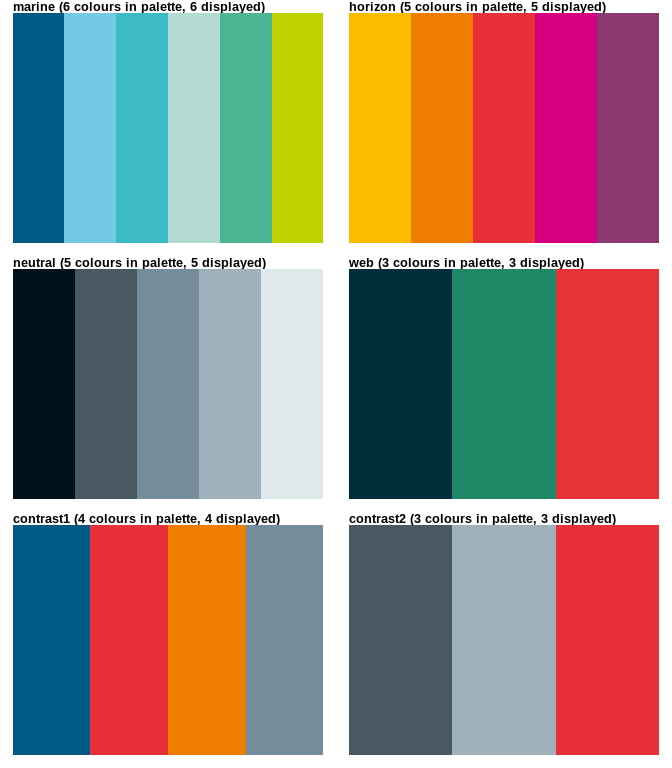

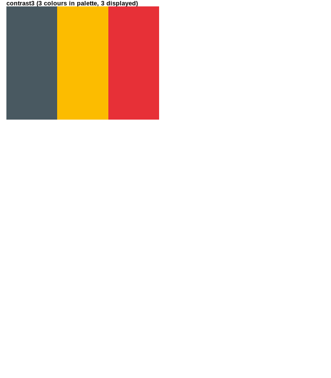

## Colour vision impairment

These plots show how each of the palettes perform for different types of colour vision impairment (using dichromat).

### Green-Blind (Deuteranopia)

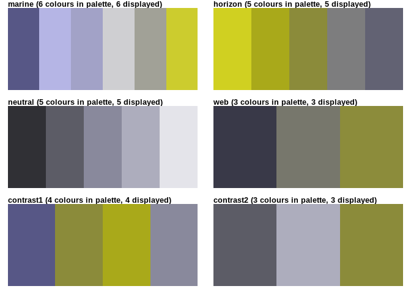

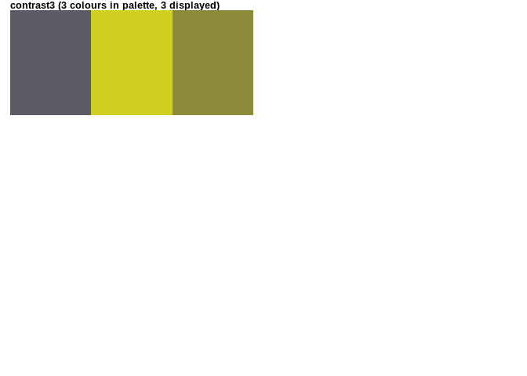

### Red-Blind (Protanopia)

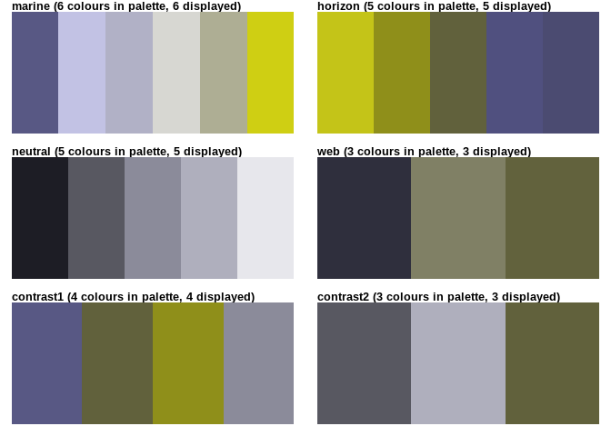

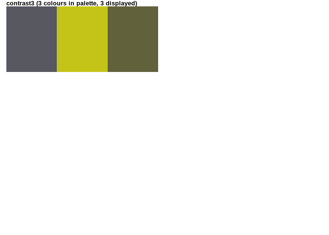

### Blue-Blind (Tritanopia)

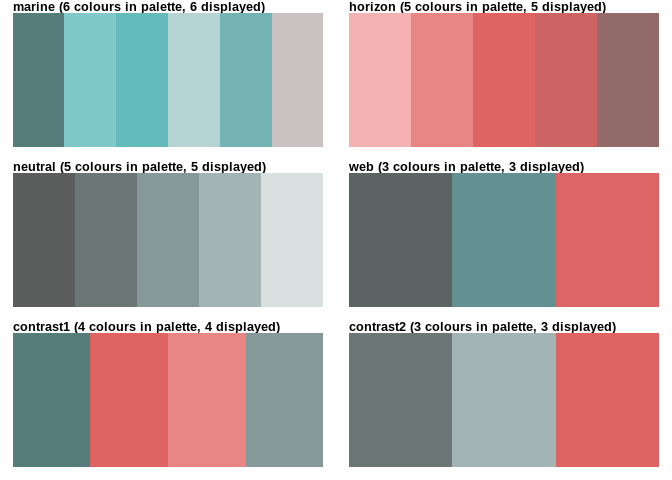

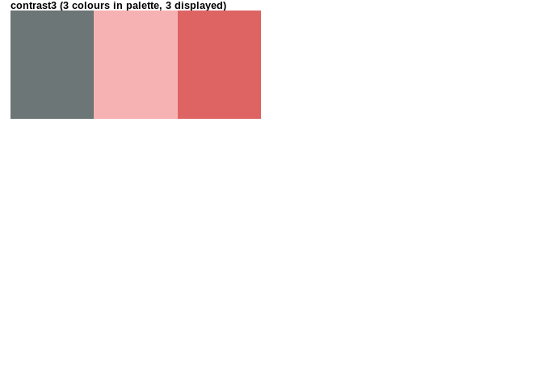

### Desaturated

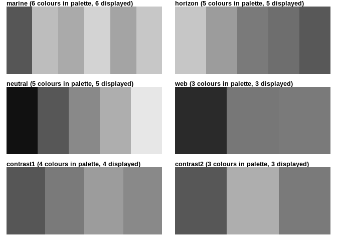

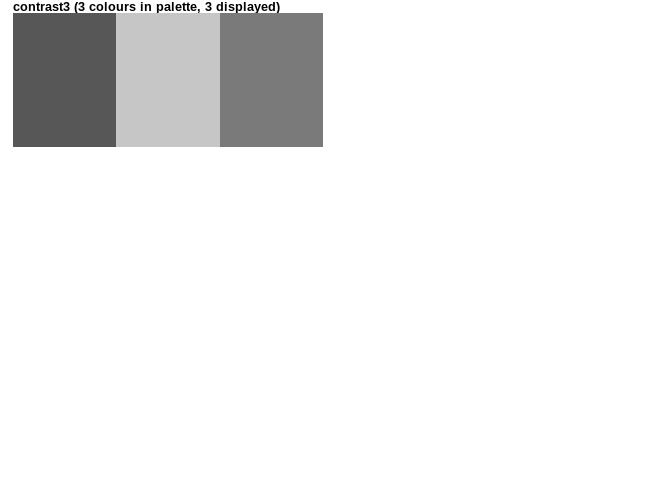

# Usage

Colours can be called directly using `uos_cols()` with a character argument for the colour name e.g. `"horizon5"`.

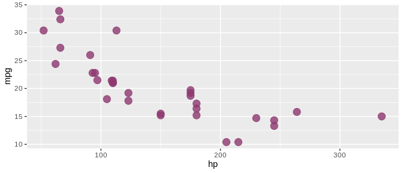

```r
ggplot(mtcars, aes(hp, mpg)) +
    geom_point(color = uos_cols("horizon5"),
               size = 4, alpha = .8)
```

The package contains color scale functions for **ggplot2** plots: `scale_color_uos()` and `scale_fill_uos()` calling one of the palettes.

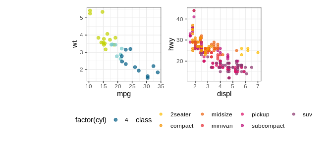

```r
# Use the marine palette for colours
p1 <- ggplot(mtcars, aes(mpg, wt)) +
   geom_point(aes(colour = factor(cyl)), size=2, alpha=0.7) +
   scale_colour_uos(palette="marine") +
    theme_bw() +
    theme(aspect.ratio=1, legend.position="bottom")

# Use the horizon palette for colours
p2 <- ggplot(data = mpg) +
   geom_point(mapping = aes(x = displ, y = hwy, color = class), alpha=0.7) +
   scale_colour_uos(palette="horizon") +
    theme_bw() +
    theme(aspect.ratio=1, legend.position="bottom")

p1 + p2
```

Here the default palette `marine` is used in a stacked bar chart using the `diamonds` data.

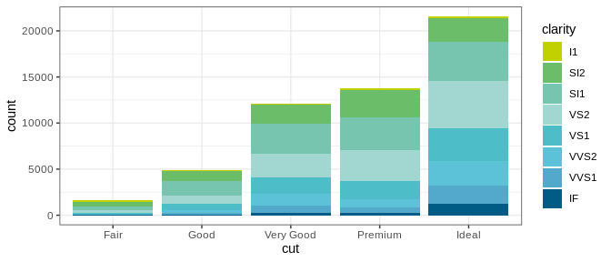

```r
 ggplot(diamonds) +
  geom_bar(aes(x = cut, fill = clarity)) +
  scale_fill_uos() +  # defaults to marine
  theme_bw()
```

It’s possible, but messy, to pick any colour combination using `uos_cols()`, but the syntax requires extracting the hex colour values using `unname()` and passing a vector of colour names as the index to `uos_cols()`

Here’s an example with the Palmer penguin data using `uos_cols()` as described above by creating a new palette called `my_cols` that is passed to `scale_colour_manual()`.

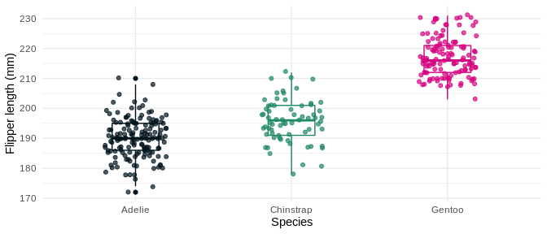

```r
# Create a new vector of colours to pass to scale_colour manual
# Use unname() to get hex codes from uos_cols()
my_cols <- unname(uos_cols()[c('black','shamrock','horizon4')])

ggplot(data = penguins, aes(x = species, y = flipper_length_mm)) +
  geom_boxplot(aes(color = species), width = 0.3, show.legend = FALSE) +
  geom_jitter(aes(color = species), alpha = 0.7, show.legend = FALSE,
              position = position_jitter(width = 0.2, seed = 0)) +
  scale_colour_manual(values = my_cols) + # pass my_cols to scale_colour_manual
  theme_minimal() +
  labs(x = "Species",
       y = "Flipper length (mm)")
```

Here is a base R `plot` using the `horizon` palette directly via the `colorRampPalette()` function.

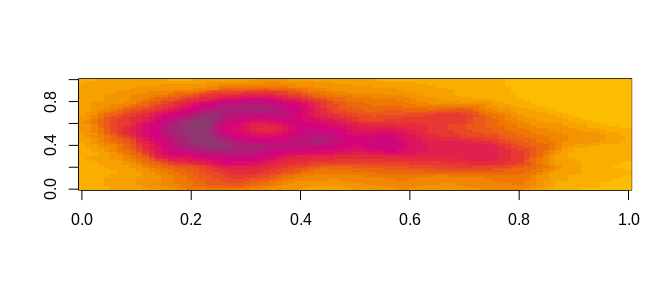

```r
pal <- colorRampPalette(uos_palettes[["horizon"]])
image(volcano, col = pal(20))
```

Here is the same plot, but by creating a new palette from specific colours as with the penguin data.

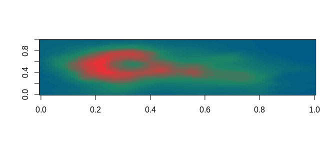

```r
# Create new palette
my_cols <- unname(uos_cols()[c('marine1','shamrock','horizon3')])

pal <- colorRampPalette(my_cols)
image(volcano, col = pal(20))
```